[figure not shown]

My Analysis

Nicole

R Markdown

# Load necessary libraries

library(caret)

## Loading required package: ggplot2

## Loading required package: lattice

library(dplyr)

##

##

## filter, lag

##

library(ggplot2)

library(randomForest)

##

## Attaching package: 'randomForest'

##

## combine

##

## margin

# Load necessary libraries

# Load the training and testing data

train_url <- "https://d396qusza40orc.cloudfront.net/predmachlearn/pml-

training.csv"

test_url <- "https://d396qusza40orc.cloudfront.net/predmachlearn/pml-

testing.csv"

train_data <- read.csv(train_url, na.strings = c("NA", "", " "))

test_data <- read.csv(test_url, na.strings = c("NA", "", " "))

Including Plots

# Remove columns with mostly NA values and irrelevant columns

train_data <- train_data %>% select_if(~ sum(is.na(.)) < 0.9 *

nrow(train_data))

train_data <- train_data[, -c(1:7)] # Remove metadata columns (e.g., ID)

set.seed(123)

trainIndex <- createDataPartition(train_data$classe, p = 0.7, list = FALSE)

training <- train_data[trainIndex,]

validation <- train_data[-trainIndex,]

# Visualize the distribution of classes

ggplot(training, aes(x = classe)) +

geom_bar() +

labs(title = "Distribution of Exercise Classes", x = "Class", y = "Count")

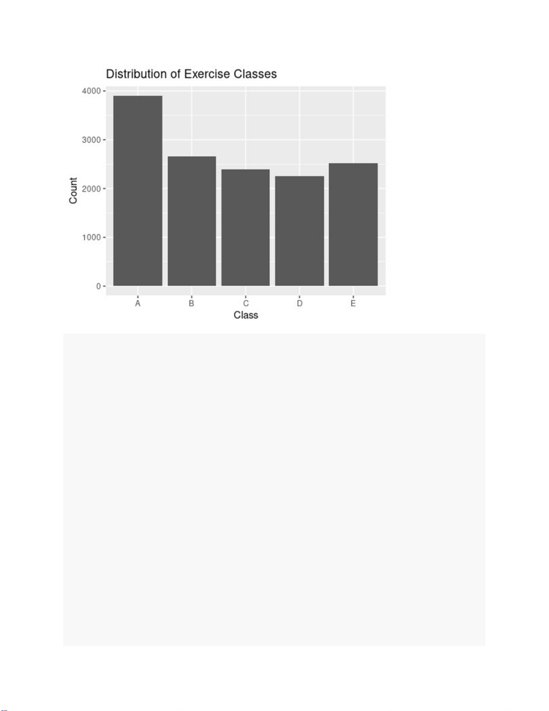

# Check correlation for feature selection

correlations <- cor(training[, sapply(training, is.numeric)])

# Train a Random Forest model

# Convert `classe` to a factor if it's not already

training$classe <- as.factor(training$classe)

validation$classe <- as.factor(validation$classe)

# Convert any character columns to numeric or remove them if irrelevant

training <- training %>% mutate_if(is.character, as.numeric)

validation <- validation %>% mutate_if(is.character, as.numeric)

# Remove columns with mostly NA values and irrelevant columns

training <- training %>% select_if(~ sum(is.na(.)) < 0.9 * nrow(training))

validation <- validation %>% select_if(~ sum(is.na(.)) < 0.9 *

nrow(validation))

# Fit the random forest model

set.seed(123)

model_rf <- randomForest(classe ~ ., data = training, importance = TRUE)

# Check model accuracy on validation set

pred_valid <- predict(model_rf, validation)

conf_matrix <- confusionMatrix(pred_valid, validation$classe)

print(conf_matrix)

[figure not shown]

## Confusion Matrix and Statistics

##

## Reference

## Prediction A B C D E

## A 1674 4 0 0 0

## B 0 1131 4 0 0

## C 0 4 1022 10 4

## D 0 0 0 954 4

## E 0 0 0 0 1074

##

## Overall Statistics

##

## Accuracy : 0.9949

## 95% CI : (0.9927, 0.9966)

## No Information Rate : 0.2845

## P-Value [Acc > NIR] : < 2.2e-16

##

## Kappa : 0.9936

##

## Mcnemar's Test P-Value : NA

##

## Statistics by Class:

##

## Class: A Class: B Class: C Class: D Class: E

## Sensitivity 1.0000 0.9930 0.9961 0.9896 0.9926

## Specificity 0.9991 0.9992 0.9963 0.9992 1.0000

## Pos Pred Value 0.9976 0.9965 0.9827 0.9958 1.0000

## Neg Pred Value 1.0000 0.9983 0.9992 0.9980 0.9983

## Prevalence 0.2845 0.1935 0.1743 0.1638 0.1839

## Detection Rate 0.2845 0.1922 0.1737 0.1621 0.1825

## Detection Prevalence 0.2851 0.1929 0.1767 0.1628 0.1825

## Balanced Accuracy 0.9995 0.9961 0.9962 0.9944 0.9963

# Define cross-validation parameters

control <- trainControl(method = "cv", number = 5)

model_cv <- train(classe ~ ., data = training, method = "rf", trControl =

control)

# Expected out-of-sample error

print(model_cv)

## Random Forest

##

## 13737 samples

## 52 predictor

## 5 classes: 'A', 'B', 'C', 'D', 'E'

##

## Resampling results across tuning parameters:

##

## mtry Accuracy Kappa

## 2 0.9901726 0.9875671

## 27 0.9909005 0.9884891

## 52 0.9859503 0.9822257

##

## Accuracy was used to select the optimal model using the largest value.

## The final value used for the model was mtry = 27.

# Load necessary libraries

library(rpart)

library(rpart.plot)

# Create a single decision tree for visualization

set.seed(123)

model_tree <- rpart(classe ~ ., data = training, method = "class")

# Plot the decision tree

rpart.plot(model_tree, type = 3, extra = 102, fallen.leaves = TRUE, main =

"Decision Tree for Classe Prediction")

# Predict on test data

predictions <- predict(model_rf, test_data)

predictions

## 1 2 3 4 5 6 7 8 9 10 11 12 13 14 15 16 17 18 19 20

## B A B A A E D B A A B C B A E E A B B B

## Levels: A B C D E

# Save predictions for submission

write.csv(predictions, "predictions.csv", row.names = FALSE)